# Poisson Regression Application

Statistical Inference II

Noah

March 6, 2018

Source: J.J. Sepkoski, Jr., M.A. Rex (1974). “Distribution of Freshwater Mussels: Coastal Rivers as Biogeographic Islands,” Systematic Zoology, Vol. 23, #2, pp. 165-188.

Using the mussels.csv dataset on Canvas>Modules, we will look at the relationship between the Area (sq. mi) and number of species.

- Using R, fit a Poisson regression. Note the parameter estimates. How does R calculate these parameter estimates?

```r
mussels <- read.csv("mussels.csv")

model <- glm(n_species ~ Area, poisson, data=mussels)

summary(model)
```

```
##
## Call:
## glm(formula = n_species ~ Area, family = poisson, data = mussels)
##
## Deviance Residuals:
##     Min       1Q   Median       3Q      Max
## -3.0766  -0.8444  -0.2056   0.5808   3.5049
##
## Coefficients:
##              Estimate Std. Error z value Pr(>|z|)
## (Intercept) 2.141e+00  6.929e-02  30.906  < 2e-16 ***
## Area        3.800e-05  6.453e-06   5.889 3.88e-09 ***
## ---
## Signif. codes:  0 '***' 0.001 '**' 0.01 '*' 0.05 '.' 0.1 ' ' 1
##
## (Dispersion parameter for poisson family taken to be 1)
##
##     Null deviance: 127.527  on 43  degrees of freedom
## Residual deviance:  96.192  on 42  degrees of freedom
## AIC: 282.22
##
## Number of Fisher Scoring iterations: 4
```

R calculates the fitted model $\lambda = E(n\_species| Area) = e^{2.141 + 0.000038 * Area}$.

I.e. for the function: $L(\beta | X, Y) = \sum\limits_{i=1}^p{(y_i * \beta^Tx_i - e^{\beta^Tx_i})}$,

R solves the equation $\frac{\partial L}{\partial \beta} = 0$.

- Using R calculate confidence interval for the $\beta_1$ parameter. How does R calculate these values?

```r
confint(model, "Area")
```

```
##        2.5 %       97.5 %
## 2.513334e-05 5.043919e-05
```

R calculates this interval using the standard error of the parameter.

```r
model.coef <- summary(model)$coefficients

print(sprintf("[%f, %f]",
              model.coef[[2,1]] - qt(0.975, 42) * model.coef[[2,2]],
              model.coef[[2,1]] + qt(0.975, 42) * model.coef[[2,2]]))
```

```
## [1] "[0.000025, 0.000051]"
```

- Interpret the point estimate of the $\beta_1$ parameter as well as the confidence interval.

$\hat{\beta_1}$ tells us that for every 1 unit increase in Area, the expected count of number of species is scaled (multiplied) by $e^{0.000038} =$ 1.000038. So the expected number of species increases as Area increases.

We interpret the confidence interval as us being 95% confident that the number of species increases between $e^{0.000025} =$ 1.000025 and $e^{0.00005} =$ 1.00005 for each additional square mile in Area.

## Categorical Predictors

- Going back to the air traffic data from last class, fit a model that includes both the **n.operator** and **age** as predictors. Interpret all parameter estimates.

```r
# Load data
air <- read.table("http://stat.ufl.edu/~winner/data/atc_error_ageexp.dat")
names(air) <- c("experience", "age", "n.error", "n.operator")

# Fit poisson regression
airModel <- glm(n.error ~ n.operator + age, family = poisson, data = air)

# Display parameter estimates
summary(airModel)$coefficients
```

```
##                  Estimate   Std. Error   z value   Pr(>|z|)
## (Intercept)  6.6899349563 1.425972e-01  46.91492 0.0000e+00
## n.operator   0.0001500652 3.803310e-06  39.45649 0.0000e+00
## age         -1.9893291684 1.136520e-01 -17.50369 1.3428e-68
```

The parameter estimate for number of operators tells us that holding age fixed, for every 1 additional operator, the expected number of errors is scaled (multiplied) by $e^{0.00015} =$ 1.00015. So the expected number of errors increases (slowly) as more operators are added.

A similar interpretation applies to the age parameter estimate, which scales the expected errors by $e^{-1.989} =$ 0.1368322. So the expected number of errors decreases quite dramatically as age switches from younger than 55 to older than 55.

- What is the expected number of errors for an air traffic control staff who works at a site with 100 operators and who is younger than 55? What is the expected number of errors for an air traffic control staff who works at a site with 100 operators and who is older than 55?

```r
m.coef <- summary(airModel)$coefficients

younger_mean_errors <- exp(m.coef[[1,1]] + m.coef[[2,1]] * 100 + m.coef[[3,1]])

print(sprintf("The expected number of errors for an air traffic control staff who works at a site with 100 operators and who is younger than 55 is %.2f.", younger_mean_errors))
```

```
## [1] "The expected number of errors for an air traffic control staff who works at a site with 100 operators and who is younger than 55 is 111.68."
```

```r
older_mean_errors <- exp(m.coef[[1,1]] + m.coef[[2,1]] * 100 + 2* m.coef[[3,1]])

print(sprintf("The expected number of errors for an air traffic control staff who works at a site with 100 operators and who is older than 55 is %.2f.", older_mean_errors))
```

```
## [1] "The expected number of errors for an air traffic control staff who works at a site with 100 operators and who is older than 55 is 15.28."
```

```r
print(sprintf("The ratio of older to younger expected errors tells us the scale factor when going from younger to older: %.3f.", older_mean_errors / younger_mean_errors))
```

```
## [1] "The ratio of older to younger expected errors tells us the scale factor when going from younger to older: 0.137."
```

```r
print(sprintf("This is the same as the exponent of the coefficient for age: %.3f.", exp(m.coef[[3,1]])))
```

```
## [1] "This is the same as the exponent of the coefficient for age: 0.137."
```

## Compare the larger model to the reduced model. Which model has better fit?

Let’s use the likelihood ratio test:

```r
airModel.smaller <- glm(n.error ~ n.operator, family = poisson, data = air)

MaxLogLik <- logLik(airModel)[1]
MaxLogLik.smaller <- logLik(airModel.smaller)[1]

print(MaxLogLik)
```

```
## [1] -211.2585
```

```r
print(MaxLogLik.smaller)
```

```
## [1] -426.8576
```

Ok, so the larger model gives a larger maximum log likelihood, as expected (it’s less negative).

```r
LR <- 2 * (MaxLogLik - MaxLogLik.smaller)
print(LR)
```

```
## [1] 431.1982
```

This statistic should follow a $\chi^2$ distribution with 1 degree of freedom (the difference in number of parameters between the two models). So what are the chances that we see a value this large or larger just by chance?

```r
pchisq(LR, 1, lower.tail = FALSE)
```

```
## [1] 8.914756e-96
```

Wow, that is small! Ok, so the larger model seems to increase the maximum likelihood more than we would expect it to if age didn’t matter. So it seems there is evidence to support that the larger model which includes age better explains the data compared to the reduced model.

```r
a <- anova(airModel.smaller, airModel)
print(a)
```

```
## Analysis of Deviance Table
##
## Model 1: n.error ~ n.operator
## Model 2: n.error ~ n.operator + age
##   Resid. Df Resid. Dev Df Deviance
## 1        10     784.61
## 2         9     353.41  1    431.2
```

```r
pchisq(a$Deviance[2], df=1, lower.tail=FALSE)
```

```
## [1] 8.914756e-96
```

### Residual Plot

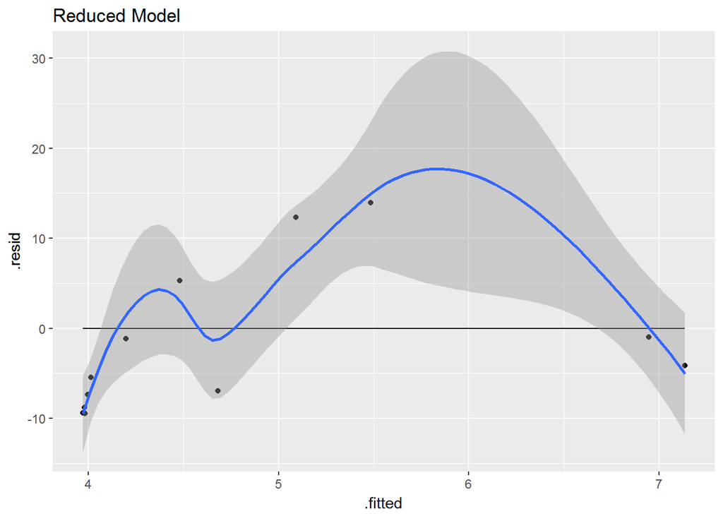

```r
airModel.smaller %>% ggplot(aes(x=.fitted, y=.resid)) +
  geom_point() +
  geom_line(y=0) +
  geom_smooth(method = "loess") +
  ggtitle("Reduced Model")
```

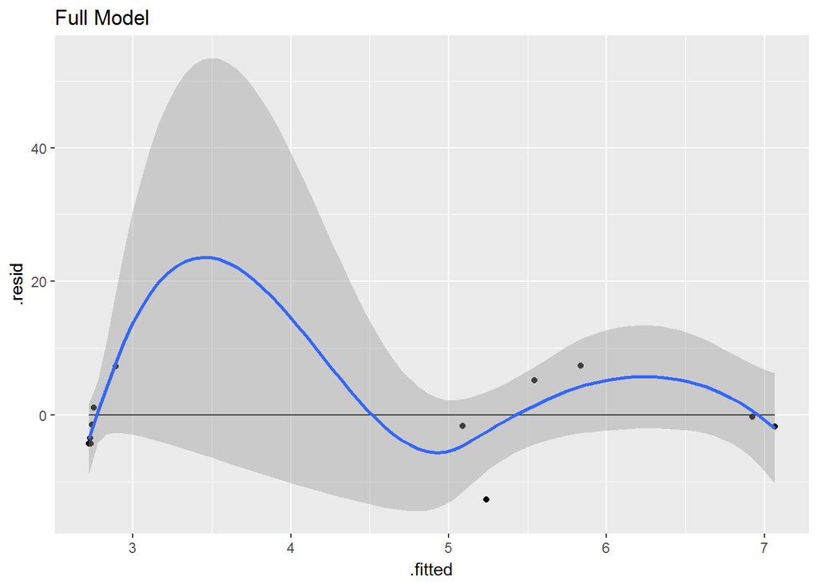

```r
airModel %>% ggplot(aes(x=.fitted, y=.resid)) +
  geom_point() +
  geom_line(y=0) +
  geom_smooth(method = "loess") +
  ggtitle("Full Model")
```